# NYPD_Project

Anonymous

07/01/2021

## NYPD Shooting Incidents Project

This project intends to investigate data on shooting incidents in the area of New York City, U.S.A. The dataset is publicly available on the website of the City of New York. It lists every shooting incident that occurred in NYC from 2006 through the end of 2020. According to the website “each record represents a shooting incident in NYC and includes information about the event, the location and time of occurrence [and] information related to suspect and victim demographics is also included”.

### Research Questions

There are a few questions that will be interesting to answer.

- How many murders are there per year in New York City?
- How many murders are there in each borough of NYC?
- How did the number of murders develop over the last years?
- Do more murders occur in specific months?
- Are there factors that increase the likelihood of the occurrence of a murder?

### Reading In Data

I start by reading in the data from the csv file that is provided by the City of New York at https://data.cityofnewyork.us/api/views/833y-fsy8/rows.csv. I need to load the **tidyverse** first.

```r
library(tidyverse)
url_in <- "https://data.cityofnewyork.us/api/views/833y-fsy8/rows.csv"
NYPD_data <- read_csv(url_in)
str(NYPD_data)
```

```
## spec_tbl_df [23,568 x 19] (S3: spec_tbl_df/tbl_df/tbl/data.frame)
##  $ INCIDENT_KEY           : num [1:23568] 2.02e+08 2.06e+08 1.93e+08 2.04e+08 2.01e+08 ...
##  $ OCCUR_DATE             : chr [1:23568] "08/23/2019" "11/27/2019" "02/02/2019" "10/24/2019" ...
##  $ OCCUR_TIME             : 'hms' num [1:23568] 22:10:00 15:54:00 19:40:00 00:52:00 ...
##   ..- attr(*, "units")= chr "secs"
##  $ BORO                   : chr [1:23568] "QUEENS" "BRONX" "MANHATTAN" "STATEN ISLAND" ...
##  $ PRECINCT               : num [1:23568] 103 40 23 121 46 73 81 67 114 69 ...
##  $ JURISDICTION_CODE      : num [1:23568] 0 0 0 0 0 0 0 0 2 0 ...
##  $ LOCATION_DESC          : chr [1:23568] NA NA NA "PVT HOUSE" ...
##  $ STATISTICAL_MURDER_FLAG: logi [1:23568] FALSE FALSE FALSE TRUE FALSE FALSE ...
##  $ PERP_AGE_GROUP         : chr [1:23568] NA "<18" "18-24" "25-44" ...
##  $ PERP_SEX               : chr [1:23568] NA "M" "M" "M" ...
##  $ PERP_RACE              : chr [1:23568] NA "BLACK" "WHITE HISPANIC" "BLACK" ...
##  $ VIC_AGE_GROUP          : chr [1:23568] "25-44" "25-44" "18-24" "25-44" ...
##  $ VIC_SEX                : chr [1:23568] "M" "F" "M" "F" ...
##  $ VIC_RACE               : chr [1:23568] "BLACK" "BLACK" "BLACK HISPANIC" "BLACK" ...
##  $ X_COORD_CD             : num [1:23568] 1037451 1006789 999347 938149 1008224 ...
##  $ Y_COORD_CD             : num [1:23568] 193561 237559 227795 171781 250621 ...
##  $ Latitude               : num [1:23568] 40.7 40.8 40.8 40.6 40.9 ...
##  $ Longitude              : num [1:23568] -73.8 -73.9 -73.9 -74.2 -73.9 ...
##  $ Lon_Lat                : chr [1:23568] "POINT (-73.80814071699996 40.697805308000056)" "POINT (-73.91857061799993 40.81869973000005)" "POINT (-73.94547965999999 40.791916091000076)" "POINT (-74.16610830199996 40.63806398200006)" ...
##  - attr(*, "spec")=
##   .. cols(
##   ..   INCIDENT_KEY = col_double(),
##   ..   OCCUR_DATE = col_character(),
##   ..   OCCUR_TIME = col_time(format = ""),
##   ..   BORO = col_character(),
##   ..   PRECINCT = col_double(),
##   ..   JURISDICTION_CODE = col_double(),
##   ..   LOCATION_DESC = col_character(),
##   ..   STATISTICAL_MURDER_FLAG = col_logical(),
##   ..   PERP_AGE_GROUP = col_character(),
##   ..   PERP_SEX = col_character(),
##   ..   PERP_RACE = col_character(),
##   ..   VIC_AGE_GROUP = col_character(),
##   ..   VIC_SEX = col_character(),
##   ..   VIC_RACE = col_character(),
##   ..   X_COORD_CD = col_number(),
##   ..   Y_COORD_CD = col_number(),
##   ..   Latitude = col_double(),
##   ..   Longitude = col_double(),
##   ..   Lon_Lat = col_character()
##   .. )
```

```r
summary(NYPD_data)
```

```
##   INCIDENT_KEY        OCCUR_DATE         OCCUR_TIME           BORO
##  Min.   :  9953245   Length:23568       Length:23568      Length:23568
##  1st Qu.: 55317014   Class :character   Class1:hms        Class :character
##  Median : 83365370   Mode  :character   Class2:difftime   Mode  :character
##  Mean   :102218616                      Mode  :numeric
##  3rd Qu.:150772442
##  Max.   :222473262
##
##     PRECINCT      JURISDICTION_CODE LOCATION_DESC      STATISTICAL_MURDER_FLAG
##  Min.   :  1.00   Min.   :0.0000    Length:23568       Mode :logical
##  1st Qu.: 44.00   1st Qu.:0.0000    Class :character   FALSE:19080
##  Median : 69.00   Median :0.0000    Mode  :character   TRUE :4488
##  Mean   : 66.21   Mean   :0.3323
##  3rd Qu.: 81.00   3rd Qu.:0.0000
##  Max.   :123.00   Max.   :2.0000
##                   NA's   :2
##  PERP_AGE_GROUP       PERP_SEX          PERP_RACE         VIC_AGE_GROUP
##  Length:23568       Length:23568       Length:23568       Length:23568
##  Class :character   Class :character   Class :character   Class :character
##  Mode  :character   Mode  :character   Mode  :character   Mode  :character
##
##
##
##
##    VIC_SEX            VIC_RACE           X_COORD_CD        Y_COORD_CD
##  Length:23568       Length:23568       Min.   : 914928   Min.   :125757
##  Class :character   Class :character   1st Qu.: 999900   1st Qu.:182565
##  Mode  :character   Mode  :character   Median :1007645   Median :193482
##                                        Mean   :1009363   Mean   :207312
##                                        3rd Qu.:1016807   3rd Qu.:239163
##                                        Max.   :1066815   Max.   :271128
##
##     Latitude       Longitude        Lon_Lat
##  Min.   :40.51   Min.   :-74.25   Length:23568
##  1st Qu.:40.67   1st Qu.:-73.94   Class :character
##  Median :40.70   Median :-73.92   Mode  :character
##  Mean   :40.74   Mean   :-73.91
##  3rd Qu.:40.82   3rd Qu.:-73.88
##  Max.   :40.91   Max.   :-73.70
##
```

### Remove Unnecessary Columns

Now I get rid of the *COORD* columns as well as the *Latitude* and *Longitude* columns and the columns *PRECINCT*, *JURISDICTION_CODE* and *LOCATION_DESC* since I do not need them in my further analysis. Since it might be interesting to analyse at what time of the day the most incidents occur, I will keep the *OCCUR_TIME* column.

```r
NYPD_data <- NYPD_data %>% select(-c('PRECINCT', 'JURISDICTION_CODE', 'LOCATION_DESC', 'X_COORD_CD', 'Y_COORD_CD', 'Latitude', 'Longitude', 'Lon_Lat'))
summary(NYPD_data)
```

```
##   INCIDENT_KEY        OCCUR_DATE         OCCUR_TIME           BORO
##  Min.   :  9953245   Length:23568       Length:23568      Length:23568
##  1st Qu.: 55317014   Class :character   Class1:hms        Class :character
##  Median : 83365370   Mode  :character   Class2:difftime   Mode  :character
##  Mean   :102218616                      Mode  :numeric
##  3rd Qu.:150772442
##  Max.   :222473262
##  STATISTICAL_MURDER_FLAG PERP_AGE_GROUP       PERP_SEX
##  Mode :logical           Length:23568       Length:23568
##  FALSE:19080             Class :character   Class :character
##  TRUE :4488              Mode  :character   Mode  :character
##
##
##
##   PERP_RACE         VIC_AGE_GROUP        VIC_SEX            VIC_RACE
##  Length:23568       Length:23568       Length:23568       Length:23568
##  Class :character   Class :character   Class :character   Class :character
##  Mode  :character   Mode  :character   Mode  :character   Mode  :character
##
##
##
```

Looking at the data we see that most columns are of the character type. However it makes sense to use factors, and a date type for the *OCCUR_DATE*.

### Date Type

Let us start with the date and time. We will take advantage of **lubridate**.

```r
library(lubridate)
NYPD_data <- NYPD_data %>% mutate(OCCUR_DATE = mdy(OCCUR_DATE))
NYPD_data <- NYPD_data %>% mutate(OCCUR_TIME = hms(OCCUR_TIME))
summary(NYPD_data)
```

```
##   INCIDENT_KEY         OCCUR_DATE           OCCUR_TIME
##  Min.   :  9953245   Min.   :2006-01-01   Min.   :0S
##  1st Qu.: 55317014   1st Qu.:2008-12-30   1st Qu.:3H 20M 0S
##  Median : 83365370   Median :2012-02-26   Median :15H 0M 0S
##  Mean   :102218616   Mean   :2012-10-03   Mean   :12H 32M 59.1318737270849S
##  3rd Qu.:150772442   3rd Qu.:2016-02-28   3rd Qu.:20H 44M 15S
##  Max.   :222473262   Max.   :2020-12-31   Max.   :23H 59M 0S
##      BORO           STATISTICAL_MURDER_FLAG PERP_AGE_GROUP
##  Length:23568       Mode :logical           Length:23568
##  Class :character   FALSE:19080             Class :character
##  Mode  :character   TRUE :4488              Mode  :character
##
##
##
##    PERP_SEX          PERP_RACE         VIC_AGE_GROUP        VIC_SEX
##  Length:23568       Length:23568       Length:23568       Length:23568
##  Class :character   Class :character   Class :character   Class :character
##  Mode  :character   Mode  :character   Mode  :character   Mode  :character
##
##
##
##    VIC_RACE
##  Length:23568
##  Class :character
##  Mode  :character
##
##
##
```

### Create Factors

First, the boroughs (*BORO*). There are 5 entries. I will create a factor from the entries. For *STATISTICAL_MURDER_FLAG* there are two possible values, *true* (murder) or *false* (no murder). I will create a factor. If we look at the *PERP_AGE_GROUP*, there are obviously missing values and strange values (1020, 940 and 224). I will look at this later on and just create a factor for now. For *PERP_SEX* there are also missing values. I will create a factor for now. I will also create factors for the remaining columns.

```r
unique(NYPD_data$BORO)
```

```
## [1] "QUEENS"        "BRONX"         "MANHATTAN"     "STATEN ISLAND"
## [5] "BROOKLYN"
```

```r
NYPD_data$BORO <- as.factor(NYPD_data$BORO)

unique(NYPD_data$STATISTICAL_MURDER_FLAG)
```

```
## [1] FALSE  TRUE
```

```r
NYPD_data$STATISTICAL_MURDER_FLAG <- as.factor(NYPD_data$STATISTICAL_MURDER_FLAG)

unique(NYPD_data$PERP_AGE_GROUP)
```

```
##  [1] NA        "<18"     "18-24"   "25-44"   "45-64"   "UNKNOWN" "65+"
##  [8] "1020"    "940"     "224"
```

```r
NYPD_data$PERP_AGE_GROUP <- as.factor(NYPD_data$PERP_AGE_GROUP)

unique(NYPD_data$PERP_SEX)
```

```
## [1] NA  "M" "F" "U"
```

```r
NYPD_data$PERP_SEX <- as.factor(NYPD_data$PERP_SEX)

unique(NYPD_data$PERP_RACE)
```

```
## [1] NA                               "BLACK"
## [3] "WHITE HISPANIC"                 "BLACK HISPANIC"
## [5] "UNKNOWN"                        "WHITE"
## [7] "ASIAN / PACIFIC ISLANDER"       "AMERICAN INDIAN/ALASKAN NATIVE"
```

```r
NYPD_data$PERP_RACE <- as.factor(NYPD_data$PERP_RACE)

unique(NYPD_data$VIC_AGE_GROUP)
```

```
## [1] "25-44"   "18-24"   "45-64"   "<18"     "65+"     "UNKNOWN"
```

```r
NYPD_data$VIC_AGE_GROUP <- as.factor(NYPD_data$VIC_AGE_GROUP)

unique(NYPD_data$VIC_SEX)
```

```
## [1] "M" "F" "U"
```

```r
NYPD_data$VIC_SEX <- as.factor(NYPD_data$VIC_SEX)

unique(NYPD_data$VIC_RACE)
```

```
## [1] "BLACK"                          "BLACK HISPANIC"
## [3] "WHITE HISPANIC"                 "WHITE"
## [5] "ASIAN / PACIFIC ISLANDER"       "UNKNOWN"
## [7] "AMERICAN INDIAN/ALASKAN NATIVE"
```

```r
NYPD_data$VIC_RACE <- as.factor(NYPD_data$VIC_RACE)

summary(NYPD_data)
```

```
##   INCIDENT_KEY         OCCUR_DATE           OCCUR_TIME
##  Min.   :  9953245   Min.   :2006-01-01   Min.   :0S
##  1st Qu.: 55317014   1st Qu.:2008-12-30   1st Qu.:3H 20M 0S
##  Median : 83365370   Median :2012-02-26   Median :15H 0M 0S
##  Mean   :102218616   Mean   :2012-10-03   Mean   :12H 32M 59.1318737270849S
##  3rd Qu.:150772442   3rd Qu.:2016-02-28   3rd Qu.:20H 44M 15S
##  Max.   :222473262   Max.   :2020-12-31   Max.   :23H 59M 0S
##
##             BORO      STATISTICAL_MURDER_FLAG PERP_AGE_GROUP PERP_SEX
##  BRONX        :6700   FALSE:19080             18-24  :5448   F   :  334
##  BROOKLYN     :9722   TRUE : 4488             25-44  :4613   M   :13305
##  MANHATTAN    :2921                           UNKNOWN:3156   U   : 1504
##  QUEENS       :3527                           <18    :1354   NA's: 8425
##  STATEN ISLAND: 698                           45-64  : 481
##                                               (Other):  57
##                                               NA's   :8459
##           PERP_RACE    VIC_AGE_GROUP   VIC_SEX
##  BLACK         :9855   <18    : 2525   F: 2195
##  WHITE HISPANIC:1961   18-24  : 9000   M:21353
##  UNKNOWN       :1869   25-44  :10287   U:   20
##  BLACK HISPANIC:1081   45-64  : 1536
##  WHITE         : 255   65+    :  155
##  (Other)       : 122   UNKNOWN:   65
##  NA's          :8425
##                            VIC_RACE
##  AMERICAN INDIAN/ALASKAN NATIVE:    9
##  ASIAN / PACIFIC ISLANDER      :  320
##  BLACK                         :16846
##  BLACK HISPANIC                : 2244
##  UNKNOWN                       :  102
##  WHITE                         :  615
##  WHITE HISPANIC                : 3432
```

There is only missing data for the perpetrator columns while the victim data is complete.

### Visualization & Analysis

For my visualizations and analyses I want to focus on the **murder cases**. Therefore I will create a new dataset that contains all the murder cases.

```r
NYC_murders <- NYPD_data %>% filter(STATISTICAL_MURDER_FLAG==T)
summary(NYC_murders)
```

```
##   INCIDENT_KEY         OCCUR_DATE           OCCUR_TIME
##  Min.   :  9953249   Min.   :2006-01-01   Min.   :0S
##  1st Qu.: 52550583   1st Qu.:2008-10-27   1st Qu.:3H 47M 0S
##  Median : 81676000   Median :2011-11-11   Median :14H 38M 0S
##  Mean   :100836910   Mean   :2012-08-22   Mean   :12H 33M 35.4679144385009S
##  3rd Qu.:150323251   3rd Qu.:2016-02-11   3rd Qu.:20H 31M 0S
##  Max.   :222466833   Max.   :2020-12-31   Max.   :23H 59M 0S
##
##             BORO      STATISTICAL_MURDER_FLAG PERP_AGE_GROUP PERP_SEX
##  BRONX        :1244   FALSE:   0              25-44  :1226   F   :  86
##  BROOKLYN     :1892   TRUE :4488              18-24  :1106   M   :2698
##  MANHATTAN    : 512                           <18    : 243   U   : 109
##  QUEENS       : 697                           45-64  : 168   NA's:1595
##  STATEN ISLAND: 143                           UNKNOWN: 110
##                                               (Other):  23
##                                               NA's   :1612
##           PERP_RACE    VIC_AGE_GROUP  VIC_SEX
##  BLACK         :1966   <18    : 319   F: 436
##  WHITE HISPANIC: 466   18-24  :1461   M:4051
##  BLACK HISPANIC: 201   25-44  :2250   U:   1
##  UNKNOWN       : 120   45-64  : 390
##  WHITE         : 103   65+    :  52
##  (Other)       :  37   UNKNOWN:  16
##  NA's          :1595
##                            VIC_RACE
##  AMERICAN INDIAN/ALASKAN NATIVE:   0
##  ASIAN / PACIFIC ISLANDER      :  81
##  BLACK                         :3144
##  BLACK HISPANIC                : 351
##  UNKNOWN                       :  17
##  WHITE                         : 177
##  WHITE HISPANIC                : 718
```

Now I will visualize the number of murders per borough.

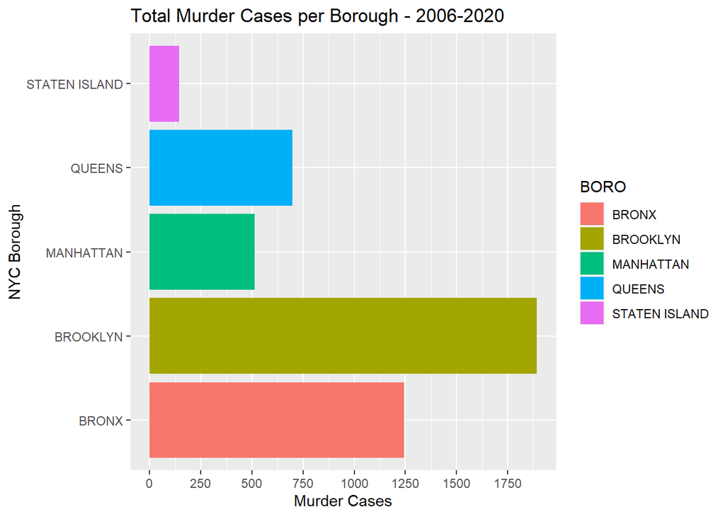

```r
ggplot(NYC_murders) +
  geom_bar(aes(y = BORO, fill = BORO)) +
  scale_x_continuous(breaks=c(seq(0, 2000, by=250)), labels=c(seq(0, 2000, by=250))) +
  labs(title = "Total Murder Cases per Borough - 2006-2020", x = "Murder Cases", y = "NYC Borough")
```

Most murders happened in Brooklyn. Now, it would be a good idea to incorporate the population into the dataset and calculate the incidents per 100,000 people. However, this would go too far for now in this project since we would need the data for all the relevant years. Instead, I will analyse the murder rate for the years 2010 and 2020. The population data is taken from https://data.cityofnewyork.us/City-Government/2020-population/t8c6-3i7b.

```r
df_pop <- read_csv("https://raw.githubusercontent.com/Mailo85/datasciencecoursera/6bd1b290f10a06e69fc42065743050e2526ef7e8/boro_pop_2010_2020.csv")
NYC_murders_2010_2020 <- group_by(NYC_murders %>% filter(year(OCCUR_DATE) %in% c(2010, 2020)), year(OCCUR_DATE), BORO) %>% summarize(n()) %>% rename("YEAR"="year(OCCUR_DATE)", "MURDERS"="n()")
NYC_murders_2010_2020 <- merge(NYC_murders_2010_2020, df_pop, by=c("YEAR", "BORO")) %>% mutate(NYC_murders_2010_2020, MURDER_RATE = round(MURDERS / POP * 100000, 2))
NYC_murders_2010_2020
```

```
##    YEAR          BORO MURDERS     POP MURDER_RATE
## 1  2010         BRONX      96 1385108        6.93
## 2  2010      BROOKLYN     182 2552911        7.13
## 3  2010     MANHATTAN      43 1585873        2.71
## 4  2010        QUEENS      75 2250002        3.33
## 5  2010 STATEN ISLAND       7  468730        1.49
## 6  2020         BRONX      86 1446788        5.94
## 7  2020      BROOKLYN     157 2648452        5.93
## 8  2020     MANHATTAN      46 1638281        2.81
## 9  2020        QUEENS      56 2330295        2.40
## 10 2020 STATEN ISLAND      16  487155        3.28
```

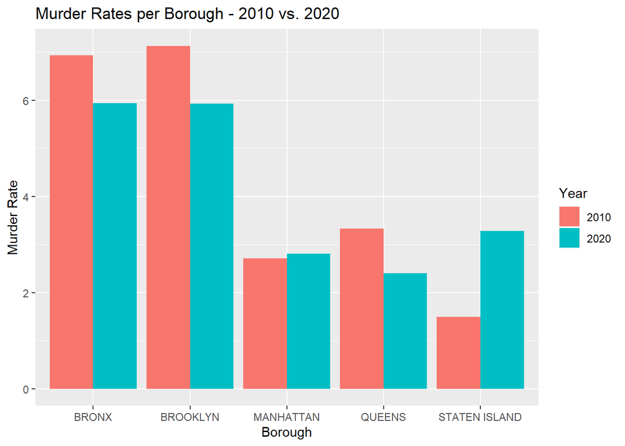

```r
ggplot(NYC_murders_2010_2020, aes(BORO, MURDER_RATE, fill=as.factor(YEAR))) +
  geom_col(position="dodge") +
  labs(title = "Murder Rates per Borough - 2010 vs. 2020", x = "Borough", y = "Murder Rate", fill = "Year")
```

While Brooklyn had the highest murder rate (per 100,000 people) in 2010, the Bronx had a slightly higher murder rate than Brooklyn and the highest overall in 2020. It is striking that Staten Island’s murder rate increased drastically from 1.49 in 2010 to 3.28 in 2020. An investigation into the reasons for this dramatic increase might be a worthwhile endeavour.

It will be interesting to see how many murder cases there were per year for the whole of NYC.

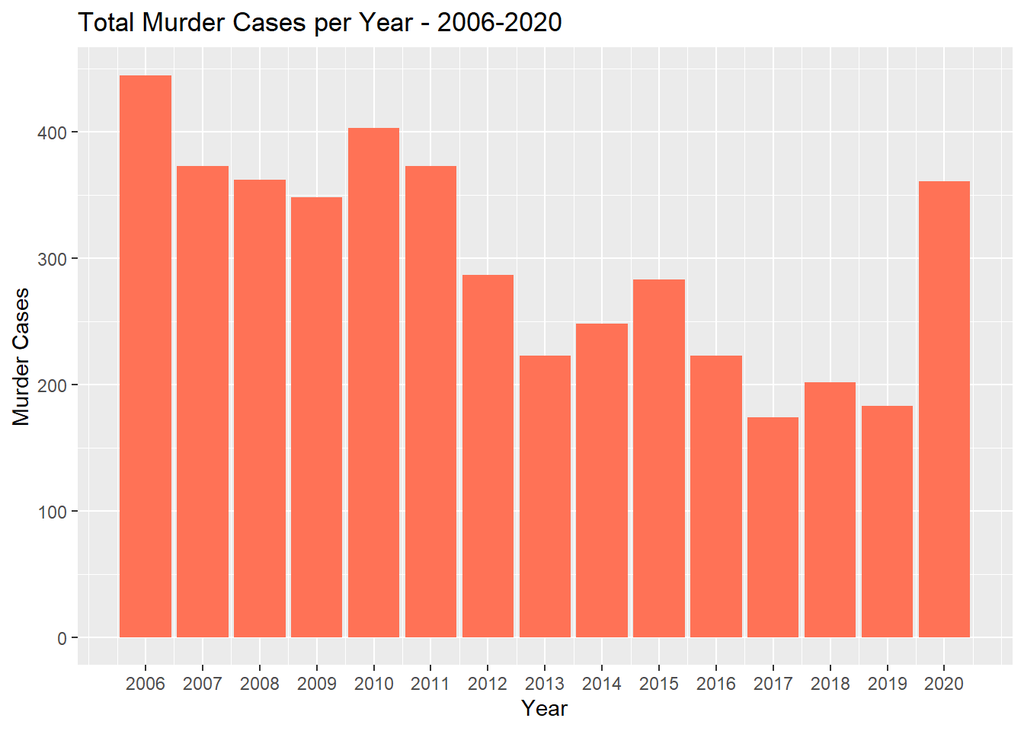

```r
ggplot(NYC_murders, aes(x=year(OCCUR_DATE))) +
  geom_bar(fill = "coral1") +
  scale_x_continuous(breaks=c(2006:2020), labels=c(2006:2020)) +
  labs(title = "Total Murder Cases per Year - 2006-2020", x = "Year", y = "Murder Cases")
```

This plot shows that the number of murders declined from 2006-2019 but then in 2020 it almost doubled compared to 2017, 2018 and 2019, respectively.

Now I want to visualize the number of murders by month to see whether there are months that are more dangerous for murders to occur than others.

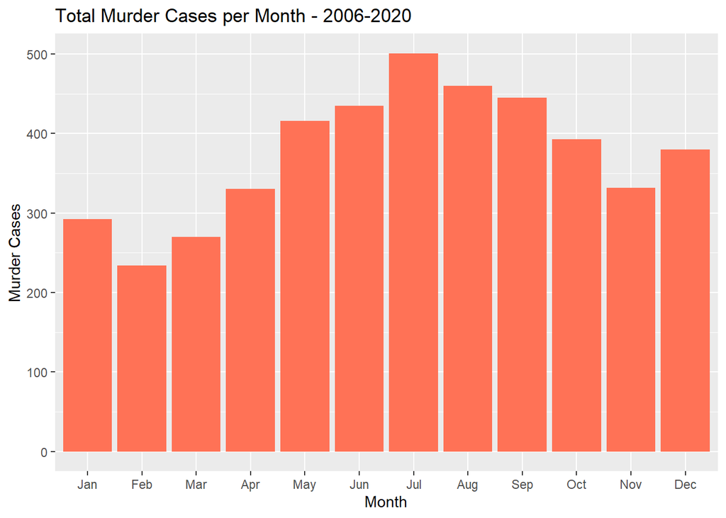

```r
ggplot(NYC_murders, aes(x=month(OCCUR_DATE))) +
  geom_bar(fill = "coral1") +
  scale_x_discrete(limits=month.abb) +
  labs(title = "Total Murder Cases per Month - 2006-2020", x = "Month", y = "Murder Cases")
```

It is obvious that the summer months seem to be the most dangerous months. On the other hand, the beginning of the year seems to be less dangerous than the end of the year when it comes to murders.

Another interesting question would be: “How did properties like age, sex and race change (or not change) over time?” And many more.

### Model

```r
murder_reg_mod <- glm(STATISTICAL_MURDER_FLAG ~ PERP_SEX + PERP_RACE + BORO, family=binomial, data=NYPD_data)
summary(murder_reg_mod)
```

```
##
## Call:
## glm(formula = STATISTICAL_MURDER_FLAG ~ PERP_SEX + PERP_RACE +
##     BORO, family = binomial, data = NYPD_data)
##
## Deviance Residuals:
##     Min       1Q   Median       3Q      Max
## -1.1509  -0.6873  -0.6552  -0.3735   2.5306
##
## Coefficients:
##                                    Estimate Std. Error z value Pr(>|z|)
## (Intercept)                       -11.41045  138.83119  -0.082   0.9345
## PERP_SEXM                          -0.26537    0.12828  -2.069   0.0386 *
## PERP_SEXU                           0.24788    0.26815   0.924   0.3553
## PERP_RACEASIAN / PACIFIC ISLANDER  10.93011  138.83134   0.079   0.9372
## PERP_RACEBLACK                     10.35326  138.83120   0.075   0.9406
## PERP_RACEBLACK HISPANIC            10.24544  138.83122   0.074   0.9412
## PERP_RACEUNKNOWN                    8.64173  138.83137   0.062   0.9504
## PERP_RACEWHITE                     11.34785  138.83125   0.082   0.9349
## PERP_RACEWHITE HISPANIC            10.55210  138.83120   0.076   0.9394
## BOROBROOKLYN                       -0.10691    0.05246  -2.038   0.0416 *
## BOROMANHATTAN                      -0.12628    0.06941  -1.819   0.0688 .
## BOROQUEENS                         -0.05925    0.06565  -0.902   0.3668
## BOROSTATEN ISLAND                  -0.09955    0.11281  -0.882   0.3775
## ---
## Signif. codes:  0 '***' 0.001 '**' 0.01 '*' 0.05 '.' 0.1 ' ' 1
##
## (Dispersion parameter for binomial family taken to be 1)
##
##     Null deviance: 14772  on 15142  degrees of freedom
## Residual deviance: 14407  on 15130  degrees of freedom
##   (8425 observations deleted due to missingness)
## AIC: 14433
##
## Number of Fisher Scoring iterations: 10
```

### Bias

The first issue that comes to my mind when thinking about bias in this dataset is regarding race. From just looking at the data one might get the impression that race could be the reason for the number of shooting incidents while in fact it depends mostly on other social and economic factors. Another source for bias could be the sex of the perpetrator or the victim. And missing values are a problem in this dataset since sex, age group and race information is missing for over 8400 perpetrators.

### Conclusion

This project has given an overview about how to begin data analysis. From reading in the data over tidying it up to visualizing some simple but interesting facts. This will establish a good foundation for future projects.